# Descripción de partos atendidos 2009 - 2015

Fuente: Datos abiertos. MinSalud

L. Paloma Rojas Saunero

[Fuente](https://datos.gob.bo/dataset/cantidad-y-cobertura-de-partos-institucionales)

# 1 Importar archivos y generar tabla unica

```r
library(tidyverse)
library(rio)
library(here)
library(tidytext)
library(plotly)
library(gt)
```

```r
data_dir <- paste0(location, "/00_datos_crudos/partos")

rda_files <- fs::dir_ls(data_dir, regexp = "\\.csv$")
```

El último archivo tiene filas vacias adicionales, una variable extra “partos_atendidos_por_provincia” y el nombre de la variable “partos por personal de salud” tiene un nombre diferente al resto de variables. Por este motivo no podemos usar directamente map_df.

```r
data <- rda_files %>%
  map(read_csv2, col_types = cols(cod_dep = col_character(),
                                      cod_mun = col_character())) %>%
  modify_in(7, select, -contains("x"),
            -contains("atendidos_por_prov")) %>%
  modify_in(7, rename, partos_atendidos_personal_salud = partos_atendidos_por_personal_de_salud_calificado)

data_completa <- map_dfr(data, bind_rows, .id = "filename")

data_completa <- data_completa %>%
  mutate(filename = str_extract(filename, "(.)(.)(.)(.).csv$"),
         year = parse_number(filename),
         cod_dep = str_remove(cod_dep, "^0"),
         cod_mun = str_remove(cod_mun, "^0")) %>%
  select(- filename)
```

# 2 Analisis descriptivo

La cobertura hace referencia al porcentaje de partos atendidos por personal de salud dentro o fuera del establecimiento, en relación con el total de partos esperados para el período analizado. Este indicador refleja la atención de partos atendidos por personal de salud institucionalmente, lo cual significa poner a disposición de las embarazadas, el personal de salud (médico, enfermera, auxiliar de enfermería y partera en servicio), la infraestructura, equipos y otros servicios del establecimiento. Mide por tanto, el nivel alcanzado en la atención al parto por personal de salud y en ambientes más seguros en periodos determinados.

## 2.1 Contar valores perdidos

```r
data_completa %>%
  summarise_all(~sum(is.na(.))) %>%
  pivot_longer(
    cols = everything(),
    names_to = "Variable",
    values_to = "Cuenta"
  ) %>%
  arrange(Cuenta) %>%
  gt()
```

| Variable | Cuenta |
| --- | --- |
| id | 0 |
| cod_dep | 0 |
| departamento | 0 |
| cod_mun | 0 |
| municipio | 0 |
| tot_gral | 0 |
| cobertura | 0 |
| year | 0 |
| vaginales | 46 |
| partos_atendidos_personal_salud | 77 |
| cesareas | 1193 |

## 2.2 Partos atendidos por el servicio de salud

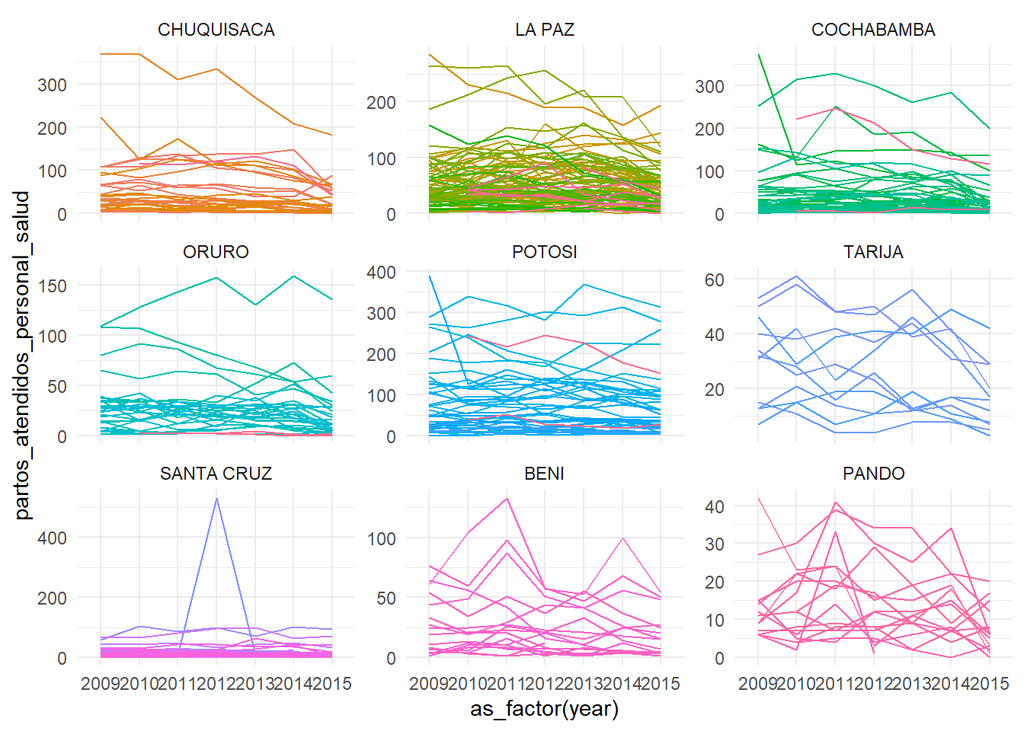

```r
data_completa %>%
  ggplot(aes(as_factor(year), partos_atendidos_personal_salud, group = as_factor(cod_mun),
             color = as_factor(cod_mun))) +
  geom_line(show.legend = FALSE) +
  facet_wrap(.~as_factor(departamento), scale = "free_y") +
  theme_minimal()
```